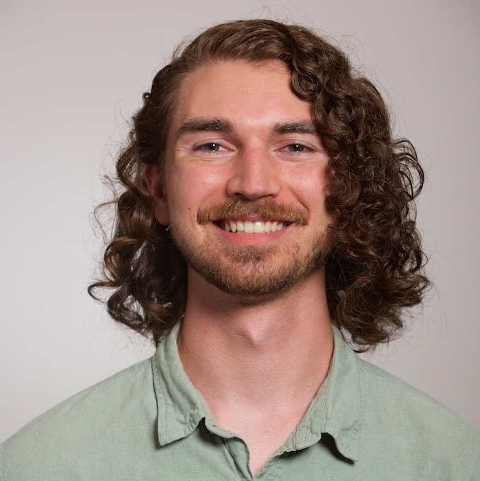

# Guy Twa

## Bio

I am a Ph.D. candidate in Genetics, Genomics, and Bioinformatics in Jeremy Day’s lab at the University of Alabama at Birmingham. I’m passionate about studying the DNA sequences that orchestrate the genome’s informational output in response to environmental context, how this output reshapes the environment in turn, and how these systems become dysregulated in disease. To study these mechanisms, I integrate multimodal genomics data using computational modeling.

## Education

**University of Alabama at Birmingham** | Birmingham, AL

Ph.D. in Biomedical Sciences August 2021 - Present

**University of Alabama at Birmingham** | Birmingham, AL

M.S. in Biomedical Sciences | May 2021

**University of Alabama at Birmingham** | Birmingham, AL

B.S. in Genetics and Genomic Sciences | May 2020

## Publications

1. Wallen ZD, Demirkan A, **Twa G**, Cohen G, Dean MN, Standaert DG, Sampson T, Payami H. Metagenomics of Parkinson’s disease implicates the gut microbiome in multiple disease mechanisms. *Nature Communications* 13, 6958 (2022). https://doi.org/10.1038/s41467-022-34667-x
2. Scull CE, **Twa G**, Zhang Y, Yang NJ, Hunter RN III, Augelli-Szafran CE, Schneider DA. Small Molecule RBI2 Disrupts Ribosome Biogenesis through Pre-rRNA Depletion. *Cancers*. 2023; 15(13):3303. https://doi.org/10.3390/cancers15133303
3. **Twa G**, Phillips III R, Robinson N, Day J. Accurate sample deconvolution of pooled snRNA-seq using sex-dependent gene expression patterns. *NAR Genomics and Bioinformatics*. 2025 Nov 22; doi: https://doi.org/10.1093/nargab/lqaf156

## Preprints

1. Tuscher J, Cleere A, Phillips III R, Newman C, **Twa G**, Robinson N, Ianov L, Sorge R, Day J. Morphine regulates astrocyte transcriptional dynamics in the ventral tegmental area by stimulation of glucocorticoid signaling. *eLife*. 2026 Apr 22; doi: https://doi.org/10.7554/eLife.110697.1